# HW1 and R basic

廖昱嘉

2018/7/8

- Introduction to R
  - 四則運算
  - 變數
  - 向量
  - 矩陣
  - 因素向量
  - 資料框dataframe
  - 清單list
- Intermediate R
  - Conditionals and Control Flow
  - Loops
  - Functions
  - The apply family
  - Utilities
- Introduction to the tidyverse
  - Data wrangling
  - Data visualization
  - Grouping and summarizing
  - Types of visualizations
- Exploratory Data Analysis
  - Exploring Categorical Data
  - Exploring Numerical Data
  - Numerical Summaries
  - Case Study
- Cleaning Data in R
  - Introduction and exploring raw data
  - Tidying data
  - Preparing data for analysis
  - Putting it all together

# Introduction to R

## 四則運算

```r
66+666
```

```
## [1] 732
```

```r
666-66
```

```
## [1] 600
```

```r
4*3
```

```
## [1] 12
```

```r
9/3
```

```
## [1] 3
```

```r
9%%5
```

```
## [1] 4
```

## 變數

變數有四種:數值，整數，邏輯值，文字 可以用函數class()來檢查此變數的種類

```r
apple<-5
```

```r
class(apple)
```

```
## [1] "numeric"
```

請注意，不同種類的變數不能相加

```r
banana<-"好吃"
```

banana不能+apple，因為一個是字串一個是數值

## 向量

使用c()來創造向量，並使用逗號分隔向量中的元素，比如:

```r
sisters<-c(6,8,10)
```

```r
fruit<-c("watermelon","pineapple","orange")
```

用names()來為向量命名，使資料更加一目瞭然

```r
names(sisters)<-c("小花","小美","小芒果")
```

```r
sisters
```

```
##   小花   小美 小芒果
##      6      8     10
```

向量裡的種類如果相同，也是可以相加的唷!  
假設小胖(pon)有的美金、台幣、黃金總共(6,6,6)

```r
pon<-c(6,6,6)
```

小美(mei)是(8,8,12)

```r
mei<-c(8,8,12)
```

```r
total<-pon+mei
```

```r
total
```

```
## [1] 14 14 18
```

我們可以用sum()這函數來相加向量內所有東西

```r
sum(mei)
```

```
## [1] 28
```

假設兩向量所有的元素一樣，種類又一樣，就可以比較!

```r
mei>pon
```

```
## [1] TRUE TRUE TRUE
```

用向量[數字]可以查詢，比如我想查詢小美有多少黃金

```r
mei[3]
```

```
## [1] 12
```

!!!R語言第一個元素是1，不是0唷  
向量[C(數字,數字)]可以查詢該向量的多個數值  
比如說我想查詢小美的美金和台幣還有黃金，他的向量編號是1和2和3，  
那就是c(1,2,3)

```r
mei[c(1,2,3)]
```

```
## [1]  8  8 12
```

上述這個方法要打三個數字，如果他是連續  
其實可以打(1:3)

```r
mei[c(1:3)]
```

```
## [1]  8  8 12
```

那如果不知道他的順序怎辦?  
其實可以從他的命名查詢

```r
names(mei)<-c("us","tw","gold")
```

接下來我想查詢小美的美金和黃金

```r
mei[c("us","gold")]
```

```
##   us gold
##    8   12
```

函數mean()可以計算該選向量或選取的向量的平均值

```r
mean(mei)
```

```
## [1] 9.333333
```

以下是R的比較運算子，就如上述比較小胖小美的美金、台幣和黃金，比較結果正確會回傳TRUE，錯了會回傳FALSE  
大於>  
小於<  
不大於<=  
不小於>=  
等於==  
不等於!=  
向量[比較後的向量]這樣的寫法可以挑出已經比好過後的值  
假設我想找小美大於10的財物  
那我可以先進行比較

```r
bigthan10<-mei>10
```

然後再以此比較出的TRUE,FALSE挑選出我要的東西

```r
mei[bigthan10]
```

```
## gold
##   12
```

這樣的好處，在於可以在我不確定該向量所有資訊時  
能快速挑選出我要的東西

## 矩陣

甚麼是矩陣阿?  
就是有列與欄的資料型態  
用matrix()創造矩陣  
以下三點(matrix的三個參數)是matrix函數的重點  
1. 第一個參數是要放進矩陣的元素1:9是(1,2,3,4,5,6,7,8,9)的簡單寫法  
2. 第二個參數byrow如果=TRUE就是填滿矩陣時已列的方向放入元素，FALSE則為以欄的方向填滿  
3. 第三個函數nrow表示矩陣有3列  
以下先用向量創造元素，在排列出一個矩陣  
分別是小已(yee)、小龍(lon)、小芳(fon)所持有的黃金和鑽石

```r
yee<-c(80,100)
```

```r
lon<-c(90,90)
```

```r
fon<-c(60,120)
```

再來組裝成矩陣

```r
property<-matrix(c(yee,lon,fon),byrow=TRUE,nrow=3)
```

```r
property
```

```
##      [,1] [,2]
## [1,]   80  100
## [2,]   90   90
## [3,]   60  120
```

用rownames()和colnames()可以為矩陣的列與欄命名

```r
keeper<-c("yee","lon","fon")
```

```r
mineral<-c("gold","diamond")
```

```r
rownames(property)<-keeper
colnames(property)<-mineral
property
```

```
##     gold diamond
## yee   80     100
## lon   90      90
## fon   60     120
```

rowSums()函數可以相加矩陣中每個列的總和，產生新的向量

```r
eachoneproperty<-rowSums(property)
eachoneproperty
```

```
## yee lon fon
## 180 180 180
```

cbind()函數可以增加矩陣的欄(前提是該向量所相加矩陣同樣數量的列)

```r
big_property<-cbind(property,eachoneproperty)
big_property
```

```
##     gold diamond eachoneproperty
## yee   80     100             180
## lon   90      90             180
## fon   60     120             180
```

rbind()函數可以增加矩陣的列

```r
tsai<-c(20,160)
fourkeeper<-rbind(property,tsai)
fourkeeper
```

```
##      gold diamond
## yee    80     100
## lon    90      90
## fon    60     120
## tsai   20     160
```

用ls()函數可以檢視工作區的內容(所有指令出的向量、矩陣…所有東西)

```r
ls()
```

```
##  [1] "apple"           "banana"          "big_property"
##  [4] "bigthan10"       "eachoneproperty" "fon"
##  [7] "fourkeeper"      "fruit"           "keeper"
## [10] "lon"             "mei"             "mineral"
## [13] "pon"             "property"        "sisters"
## [16] "total"           "tsai"            "yee"
```

colSums()相對於rowSums()，是用來相加欄的!

```r
minetotal<-colSums(property)
minetotal
```

```
##    gold diamond
##     230     310
```

矩陣的查詢  
矩陣[1,2]可以選出該矩陣第一列第二欄的元素  
矩陣[1:3,2:4]可以選出該矩陣第一列至第三列與第二欄至第四欄的元素  
矩陣[,1]會列出第一欄的所有元素  
矩陣[1,]則會列出第一列的所有元素  
矩陣的計算  
矩陣是可以計算的!!!比如黃金和鑽石每公斤都是10000元

```r
money<-property*10000
money
```

```
##      gold diamond
## yee 8e+05 1000000
## lon 9e+05  900000
## fon 6e+05 1200000
```

但如果黃金和鑽石每公斤價格不一樣呢??  
還是可以計算的

```r
price<-c(20,600)
true_money<-property*price
true_money
```

```
##      gold diamond
## yee  1600   60000
## lon 54000    1800
## fon  1200   72000
```

請注意，上述矩陣運算不是標準的，標準矩陣運算子要使用%*%喔

## 因素向量

因素向量是用來儲存類別型變數的統計資料，類別型變數與連續型變數最主要的差異在於  
類別型變數有類別個數的上限!!!而連續型變數則會有無窮多的個數  
一個好的因素向量範例是生理性別，每一個觀測值都可以被分類成生理男性或生理女性  
factor()函數來宣告因素向量，以下以生理性別作範例

```r
gender_vector<-c("Male","Female","Female","Male","Male")
factor_gender_vector<-factor(gender_vector)
factor_gender_vector
```

```
## [1] Male   Female Female Male   Male
## Levels: Female Male
```

因素向量的類別型變數又可分為名目類別型變數和順序類別型變數，比如有個因素向量有五種動物，你無法比較各種動物間的好壞，他就為名目類別型變數，反之，順序類別型變數有天生的比較特性，比如溫度分低中高，中就比低大，高就比中大。  
用levels()這個函數來改變因素向量級別的名稱，以下以生理性別作範例，請注意改變名稱時輸入順序非常重要，R預設是以字母順序排列，所以要把male>M，femal>F，順序要是先f在m，千萬別反了，不然資料就跟著反了。

```r
levels(factor_gender_vector)<-c("F","M")
factor_gender_vector
```

```
## [1] M F F M M
## Levels: F M
```

summary()函數可以使我們快速得到一組資料的摘要，以下仍然以生理性別為範例，用summary可以讓我們快速知道有多少生理男性和生理女性。

```r
summary(gender_vector)
```

```
##    Length     Class      Mode
##         5 character character
```

```r
summary(factor_gender_vector)
```

```
## F M
## 2 3
```

從上面結果可以知道，如果summary因素向量，他會不同於一般向量，把每個類別的個數顯示出來  
順序型因素向量比較  
以下用速度作為介紹

```r
speed<-c("fast","slow","slow","fast","insane")
```

在factor()在加入ordered和levels才能使因素向量指定為順序型因素向量

```r
factor_speed<-factor(speed,ordered = TRUE, levels=c("slow","fast","insane"))
factor_speed
```

```
## [1] fast   slow   slow   fast   insane
## Levels: slow < fast < insane
```

```r
summary(speed)
```

```
##    Length     Class      Mode
##         5 character character
```

```r
summary(factor_speed)
```

```
##   slow   fast insane
##      2      2      1
```

順序型因素向量才能比較，名目型因素向量步行比較

```r
da2<-factor_speed[2]
da5<-factor_speed[5]
da2 > da5
```

```
## [1] FALSE
```

## 資料框(dataframe)

矩陣中的元素是相同的，資料框可以是不同的!!!  
因為他的觀測值儲存為列，變數儲存為欄!!!  
head()函數可以使你先觀察前六個資料  
str()函數可以告訴我們資料框的訊息  
包括觀測值的總數、變數的總數、變數名稱清單、變數的資料類型和前幾個觀測值，建議拿到一筆資料時都限用此函數來瞭幾這筆資料的樣態  
data.frame()函數就是來建立資料框的!以下以太陽系八大行星為範例

```r
name<-c("Mercury","Venus","Earth","Mars","Jupiter","Saturn","Uranus","Neptune")
type<-c("Terrestrial planet", "Terrestrial planet", "Terrestrial planet", "Terrestrial planet", "Gas giant", "Gas giant", "Gas giant", "Gas giant")
diameter <- c(0.382, 0.949, 1, 0.532, 11.209, 9.449, 4.007, 3.883)
rotation <- c(58.64, -243.02, 1, 1.03, 0.41, 0.43, -0.72, 0.67)
rings <- c(FALSE, FALSE, FALSE, FALSE, TRUE, TRUE, TRUE, TRUE)
planet_df<-data.frame(name,type,diameter,rotation,rings)
planet_df
```

```
##      name               type diameter rotation rings
## 1 Mercury Terrestrial planet    0.382    58.64 FALSE
## 2   Venus Terrestrial planet    0.949  -243.02 FALSE
## 3   Earth Terrestrial planet    1.000     1.00 FALSE
## 4    Mars Terrestrial planet    0.532     1.03 FALSE
## 5 Jupiter          Gas giant   11.209     0.41  TRUE
## 6  Saturn          Gas giant    9.449     0.43  TRUE
## 7  Uranus          Gas giant    4.007    -0.72  TRUE
## 8 Neptune          Gas giant    3.883     0.67  TRUE
```

dataframe的查詢  
資料框[1,2]將此dataframe第一列第二欄的元素選出  
資料框[1:3,2:4]將dataframe第一到第三列嶼第二至第四欄的元素選出  
資料框[1,]會把第一列所有元素選出

```r
planet_df[1,3]
```

```
## [1] 0.382
```

這是水星的直徑

```r
planet_df[4,]
```

```
##   name               type diameter rotation rings
## 4 Mars Terrestrial planet    0.532     1.03 FALSE
```

這是火星所有的資訊  
我們也可以用dataframe的名稱來進行查詢，在我們不知道他的欄位的時候

```r
planet_df[1:5,"diameter"]
```

```
## [1]  0.382  0.949  1.000  0.532 11.209
```

$符號的運用  
如果要選出diameter變數的所有值可以這樣子

```r
planet_df[,3]
```

```
## [1]  0.382  0.949  1.000  0.532 11.209  9.449  4.007  3.883
```

```r
planet_df[,"diameter"]
```

```
## [1]  0.382  0.949  1.000  0.532 11.209  9.449  4.007  3.883
```

```r
planet_df$diameter
```

```
## [1]  0.382  0.949  1.000  0.532 11.209  9.449  4.007  3.883
```

邏輯值(TRUE,FALSE)的向量在dataframe的查詢是可以快速使用的，假設我們要找有環的星球，可以這樣做

```r
planet_df[rings,]
```

```
##      name      type diameter rotation rings
## 5 Jupiter Gas giant   11.209     0.41  TRUE
## 6  Saturn Gas giant    9.449     0.43  TRUE
## 7  Uranus Gas giant    4.007    -0.72  TRUE
## 8 Neptune Gas giant    3.883     0.67  TRUE
```

subset()函數可以更快速做到上述的答案  
subset(所選dataframe,所搜尋情況)  
比如

```r
subset(planet_df,subset = rings)
```

```
##      name      type diameter rotation rings
## 5 Jupiter Gas giant   11.209     0.41  TRUE
## 6  Saturn Gas giant    9.449     0.43  TRUE
## 7  Uranus Gas giant    4.007    -0.72  TRUE
## 8 Neptune Gas giant    3.883     0.67  TRUE
```

請注意subset所蒐尋的情況不只搜尋欄位名稱，還可以進行比較

```r
subset(planet_df,diameter<1)
```

```
##      name               type diameter rotation rings
## 1 Mercury Terrestrial planet    0.382    58.64 FALSE
## 2   Venus Terrestrial planet    0.949  -243.02 FALSE
## 4    Mars Terrestrial planet    0.532     1.03 FALSE
```

這樣可以選出直徑<1的星球  
排序  
用order()函數可以讓某個欄位排序資料框的觀測值

```r
a<-c(6,10,8)
order(a)
```

```
## [1] 1 3 2
```

```r
a[order(a)]
```

```
## [1]  6  8 10
```

這當然也能用在資料框(dataframe)

```r
positions<-order(planet_df$diameter)
planet_df[positions,]
```

```
##      name               type diameter rotation rings
## 1 Mercury Terrestrial planet    0.382    58.64 FALSE
## 4    Mars Terrestrial planet    0.532     1.03 FALSE
## 2   Venus Terrestrial planet    0.949  -243.02 FALSE
## 3   Earth Terrestrial planet    1.000     1.00 FALSE
## 8 Neptune          Gas giant    3.883     0.67  TRUE
## 7  Uranus          Gas giant    4.007    -0.72  TRUE
## 6  Saturn          Gas giant    9.449     0.43  TRUE
## 5 Jupiter          Gas giant   11.209     0.41  TRUE
```

這樣資料框就已直徑小到大做排序囉

## 清單list

清單可以蒐集多樣性的物件，包含矩陣、向量、資料框甚至清單!!!這些物件不需要彼此相關，清單可謂超級資料類型阿，任何資訊都可以儲存在清單中!  
假設我把前面所學的向量(妹妹們)、矩陣(黃金與鑽石)、資料框(八大行星)和在一個清單上  
我必須要用list()函數

```r
my_list<-list(sisters,property,planet_df)
my_list
```

```
## [[1]]
##   小花   小美 小芒果
##      6      8     10
##
## [[2]]
##     gold diamond
## yee   80     100
## lon   90      90
## fon   60     120
##
## [[3]]
##      name               type diameter rotation rings
## 1 Mercury Terrestrial planet    0.382    58.64 FALSE
## 2   Venus Terrestrial planet    0.949  -243.02 FALSE
## 3   Earth Terrestrial planet    1.000     1.00 FALSE
## 4    Mars Terrestrial planet    0.532     1.03 FALSE
## 5 Jupiter          Gas giant   11.209     0.41  TRUE
## 6  Saturn          Gas giant    9.449     0.43  TRUE
## 7  Uranus          Gas giant    4.007    -0.72  TRUE
## 8 Neptune          Gas giant    3.883     0.67  TRUE
```

一樣，用names()函數來為list命名

```r
names(my_list)<-c("sis","good","planet")
my_list
```

```
## $sis
##   小花   小美 小芒果
##      6      8     10
##
## $good
##     gold diamond
## yee   80     100
## lon   90      90
## fon   60     120
##
## $planet
##      name               type diameter rotation rings
## 1 Mercury Terrestrial planet    0.382    58.64 FALSE
## 2   Venus Terrestrial planet    0.949  -243.02 FALSE
## 3   Earth Terrestrial planet    1.000     1.00 FALSE
## 4    Mars Terrestrial planet    0.532     1.03 FALSE
## 5 Jupiter          Gas giant   11.209     0.41  TRUE
## 6  Saturn          Gas giant    9.449     0.43  TRUE
## 7  Uranus          Gas giant    4.007    -0.72  TRUE
## 8 Neptune          Gas giant    3.883     0.67  TRUE
```

其實阿，當初在列清單，使用lsit()函數時，就可以在list(名字1=所加入項目1,名字2=所加入項目2….)來進行命名了 清單的選取非常不值觀  
假設我想選取我三位妹妹其中一位小芒果(他在第一個清單，他是向量裡的第三位)

```r
my_list[[1]][3]
```

```
## 小芒果
##     10
```

```r
real_list<-c(my_list,date="2017年7月8日")
real_list
```

```
## $sis
##   小花   小美 小芒果
##      6      8     10
##
## $good
##     gold diamond
## yee   80     100
## lon   90      90
## fon   60     120
##
## $planet
##      name               type diameter rotation rings
## 1 Mercury Terrestrial planet    0.382    58.64 FALSE
## 2   Venus Terrestrial planet    0.949  -243.02 FALSE
## 3   Earth Terrestrial planet    1.000     1.00 FALSE
## 4    Mars Terrestrial planet    0.532     1.03 FALSE
## 5 Jupiter          Gas giant   11.209     0.41  TRUE
## 6  Saturn          Gas giant    9.449     0.43  TRUE
## 7  Uranus          Gas giant    4.007    -0.72  TRUE
## 8 Neptune          Gas giant    3.883     0.67  TRUE
##
## $date
## [1] "2017年7月8日"
```

- 回目錄

# Intermediate R

## Conditionals and Control Flow

Equality

```r
TRUE == FALSE # 比較邏輯值
```

```
## [1] FALSE
```

```r
-6*14 != 17-101 # 比較數值
```

```
## [1] FALSE
```

```r
"useR" == "uset" # 比較文字
```

```
## [1] FALSE
```

```r
TRUE == 1 #比較邏輯值和數字
```

```
## [1] TRUE
```

watch out!Since TRUE coerces to1= 1 under the hood,  
TRUE == 1 evaluates to TRUE.Make sure not to mix up ==(comparison) amd =(assignment).== is what need to check the equality of R objects. 比大小

```r
-6*5+2 >=-10+1
```

```
## [1] FALSE
```

```r
"raining" <= "raining dogs"#先比較開頭字母，在比較字串長度
```

```
## [1] TRUE
```

```r
TRUE > FALSE # TRUE是1 FALSE是0，1當然大於0
```

```
## [1] TRUE
```

若兩向量(vector)相同數量也相同種類，那就可以比較  
其實不只向量啦，矩陣值裡面都一樣也可以比較  
Logical operators &就是and要所有都TRUE才會顯示TRUE  
|就是or其中一個是TRUE就會顯示TRUE !叫做邏輯非運算符會把得出的答案顛倒  
&&只比較向量中第一個值唷  
||也一樣只比較向量中第一個值  
所以&&和||在向量比較後都只會傳回一個值唷

```r
c(TRUE,TRUE,FALSE)&c(TRUE,FALSE,FALSE)
```

```
## [1]  TRUE FALSE FALSE
```

```r
c(TRUE,TRUE,FALSE)|c(TRUE,FALSE,FALSE)
```

```
## [1]  TRUE  TRUE FALSE
```

```r
!TRUE
```

```
## [1] FALSE
```

```r
c(TRUE,TRUE,FALSE)&&c(TRUE,FALSE,FALSE)
```

```
## [1] TRUE
```

```r
c(TRUE,TRUE,FALSE)||c(TRUE,FALSE,FALSE)
```

```
## [1] TRUE
```

Conditional Statements  
這裡我們要認識if,else if,else這三個語法  
請看以下程式碼，他綜合了if,else if,else的要素

```r
a=66
if(a<10){
  if(a<5){
    result<-"extra small"
  }else{
    result<-"small"
  }
}else if (a<100){
  result<-"medium"
}else{
  result<-"large"
}
print(result)
```

```
## [1] "medium"
```

請注意以下幾點  
1. 一定要對齊(就是照著換行後他給的位置寫)  
2. 前面的過關了(TRUE時)，後面的不管多精細多正確都不會被跑到(因為她只要有第一個TRUE時，就會跳出這個if式子)

## Loops

while loop  
以下程式碼將會有while用法和break使用時機

```r
i<-1
while(i<=10){
  print(3*i)
  if(3*i%%8==0){
    break
  }
  i<-i+1
}
```

```
## [1] 3
## [1] 6
## [1] 9
## [1] 12
## [1] 15
## [1] 18
## [1] 21
## [1] 24
```

如果沒有這個if和break，這個while迴圈會一直跑，跑到i變11  
因為當i==11的時候while(i<=10)會不成立(FALSE)，於是跳出這個迴圈  
但加了這個if和break，只要3i能被8整除，break就會強制帶離這個while迴圈  
所以我們可以看到她到24(38)就不繼續到i<-11了

for loop  
先以一個向量來介紹兩種for迴圈的寫法

```r
linkedin<-c(16,9,13,5,2,17,14)
for(link in linkedin){
  print(link)
}#typeA
```

```
## [1] 16
## [1] 9
## [1] 13
## [1] 5
## [1] 2
## [1] 17
## [1] 14
```

```r
for(i in 1:length(linkedin)){
  print(linkedin[i])
}#typeB
```

```
## [1] 16
## [1] 9
## [1] 13
## [1] 5
## [1] 2
## [1] 17
## [1] 14
```

兩種顯示結果都一樣，但是A比較值觀，B比較多功能和發展性  
for迴圈當然不只可以用在向量，也可以用在清單和矩陣…  
接下來要介紹break和next的差別  
break用法跟while迴圈一樣，會使迴圈強制跳出  
next很特別，他會跳過此項，然後繼續跑下面的項目

```r
for(li in linkedin){
  if(li>10){
    print("你好紅")
  }else{
    print("多爭取點關注度")
  }
  if(li>16){
    print("紅翻天了你")
    break
  }
  if(li<5){
    print("有點邊緣喔")
    next
  }
  print(li)
}
```

```
## [1] "你好紅"
## [1] 16
## [1] "多爭取點關注度"
## [1] 9
## [1] "你好紅"
## [1] 13
## [1] "多爭取點關注度"
## [1] 5
## [1] "多爭取點關注度"
## [1] "有點邊緣喔"
## [1] "你好紅"
## [1] "紅翻天了你"
```

當數值是2(<5)時候，他只會說有點邊緣，不會print出他的數值(因為有next)，直接跳到下一個17，而17是紅翻天了你，接下來進行break，所以最後一個數值14不會跑

## Functions

如何查詢函數?  
使用help(函數)  
?函數  
args(函數)可以使你快速了解想知道函數的寫法  
以下用mean()函數作介紹  
mean函數晚整寫法是  
mean(x, trim = 0 ,na.rm=FALSE)  
X是你一定要填的數值，如果沒有填R會給你error  
後面兩個有默認值，如果你沒填R就會當作你用默認值  
所以後面兩個也較optional arguments

```r
facebook<-c(17,NA,5,16,8,13,14)
mean(facebook)
```

```
## [1] NA
```

```r
mean(facebook,na.rm=TRUE)
```

```
## [1] 12.16667
```

由以上的程式碼，可以知道改動默認值的差異  
此外，函數是可以套著用的!疊加使用，比如  
print(paste(“your speed is”,speed))  
以下呈上面程式碼來作例子

```r
linkedin<-c(16,9,13,5,NA,17,14)
mean(abs(linkedin-facebook),na.rm=TRUE)
```

```
## [1] 4.8
```

Writing Functions自訂函數  
所自訂函數<- function(argument(可設定默認值)){  
此自訂函數的內容  
}  
1. 可以不要有argument唷  
2. 變數跑過函數會跑出結果，但此結果不會改變變數，變數仍然跟跑函數前一樣，除非他被重新指定(assign)才會變  
3. 函數可以很複雜(廢話)，他能包含住前面所學的迴圈，比較運算子甚至其他自訂函數!

```r
hello<-function(){
  print("HI!!!!")
  return(TRUE)
}
hello()#要點1
```

```
## [1] "HI!!!!"
```

```
## [1] TRUE
```

```r
triple <- function(x){
  x<-3*x
}
a<-5
triple(a)#進入函數後的結果
a#要點2
```

```
## [1] 5
```

```r
linkedin<-c(16,9,13,5,2,17,14)
facebook<-c(17,7,5,16,8,13,14)
interpret<- function(num_views){
  if(num_views>15){
    print("你好紅")
    return(num_views)
  }else{
    print("多爭取點關注度")
    return(0)
  }
}
interpret_all<- function(views, return_sum=TRUE){
  count<- 0
  for(v in views){
    count<-count+interpret(v)
  }
  if(return_sum==TRUE){
    return(count)
  }else{
    return(NULL)
  }
}#要點3
interpret_all(linkedin)
```

```
## [1] "你好紅"
## [1] "多爭取點關注度"
## [1] "多爭取點關注度"
## [1] "多爭取點關注度"
## [1] "多爭取點關注度"
## [1] "你好紅"
## [1] "多爭取點關注度"
```

```
## [1] 33
```

```r
interpret_all(facebook)
```

```
## [1] "你好紅"
## [1] "多爭取點關注度"
## [1] "多爭取點關注度"
## [1] "你好紅"
## [1] "多爭取點關注度"
## [1] "多爭取點關注度"
## [1] "多爭取點關注度"
```

```
## [1] 33
```

最後一個程式碼可以表達社群網站瀏覽次數高的日子的總和  
其內嵌了迴圈、比較運算子和其他自訂函數  
R package!!!  
R package就是裡面有一堆函數，你可以用search()來觀看自己目前擁有多少package，就可以知道自己有那些函數  
R 一開始就會給你一些基本的package，但沒有的就必須要自己裝，以下兩個函數非常重要:  
1. install.packages()安裝  
2. library()載入  
以下用安裝ggplot2作範例  
install.packages(“ggplot2”)  
library(ggplot2)  
qplot(mtcars$wt,mtcars$hp)  
search()  
從search的結果知道ggplot2被裝進來了，這樣我們才可以畫圖表。  
library()和require()這兩個函數其實蠻不挑剔的，  
library(rjson)和library(“rjson”)會有一樣的結果。

## The apply family

lappy!!!  
基本語法lapply(x,fun,…)  
lapply函數是最基礎循環操作函數之一，對list,dataframe數據進行循環，並返回x長度同樣的list結構做為展現  
!!!請記住fun代表的是函數，你塞哪個函數，lapply就會對你給的x中每一個值進行此函數的運作!!!  
這裡有個額外的插曲，叫做anonymous functions，就是匿名函數，也一樣可以用在lapply，這樣就不用再額外寫自訂函數再加進去了!  
以下為anonymous functions的範例

```r
triple<-function(x){3*x}#named function
function(x){3*x}#anonymous function
```

```
## function(x){3*x}
```

```r
lapply(list(1,2,3),function(x){3*x})
```

```
## [[1]]
## [1] 3
##
## [[2]]
## [1] 6
##
## [[3]]
## [1] 9
```

```r
lapply(list(1,2,3),triple)
```

```
## [[1]]
## [1] 3
##
## [[2]]
## [1] 6
##
## [[3]]
## [1] 9
```

跑出來的結果是一樣的，只是一個有取名一個沒取名字而已  
另外如果你的fun要設定默認值，lapply也是可追加的!

```r
multiply<-function(x,factor){
  x*factor
}
lapply(list(1,2,3),multiply,factor=3)
```

```
## [[1]]
## [1] 3
##
## [[2]]
## [1] 6
##
## [[3]]
## [1] 9
```

sapply!!!  
sapply是一個簡化版的lapply，其曾將兩個函數simplify和USE.NAMES，主要就是讓輸出起來更加好看  
請注意sapply返回值為向量，而不是list對象  
如果把simplify=FALSE,USE.NAMES=FALSE那就跟lapply一樣了  
sapply也可以產出矩陣(當(simplify=array)或默認情況)  
vapply!!!  
vapply類似於sapply，但他多提供了fun.value參數，用來控制返回值得行名，這樣可以讓程序更健壯  
vapply() can be considered a more robust version of sapply(), because you explicitly restrict the output of the function you want to apply.  
簡而言之，vapply比sapply更加嚴謹如果你的fun.value無法對應到你的fun，他會跳出錯誤訊息，不像sapply因為沒這道手續而繼續跑。  
輸出比較  
lapply()  
apply dunction over list or vector  
output=list  
sapply()  
apply dunction over list or vector  
!try to simplify list to array  
vapply()  
apply dunction over list or vector  
explicitly specify output format

## Utilities

Mathematical utilities  
1. abs()取絕對值  
2. sum()加總  
3. mean()取平均數  
4. round()四捨五入進整數  
Data utilities  
1. seq()Generate sequences, by specifying the from, to, and by arguments.  
2. rep()replicate(複製)向量或清單(list)中的元素  
3. sort()升冪排列一個向量裡的值，字串或邏輯值也可以唷  
4. rev()reverse(逆轉)顛倒再資料裡面的元素順序  
5. str()展現資料結構  
6. append()把東西加入向量或清單(list)  
7. is.()檢查這個函數的種類  
8. as.()改變一個R object到另一種類  
9. unlist()把一個清單拆平(flatten)成一個向量  
Regular Expression  
以下用各種email的搜索來介紹RE用法和相關函數

```r
emails <- c("john.doe@ivyleague.edu","education@world.gov", "dalai.lama@peace.org","invalid.edu","quant@bigdatacollege.edu","cookie.monster@sesame.tv")
grepl("edu",emails)
```

```
## [1]  TRUE  TRUE FALSE  TRUE  TRUE FALSE
```

```r
hits<-grep("edu",emails)
emails[hits]
```

```
## [1] "john.doe@ivyleague.edu"   "education@world.gov"
## [3] "invalid.edu"              "quant@bigdatacollege.edu"
```

上述情況會把education…的那個也抓進來，但其實我要的是結尾是.edu的mail，以下改變RE可以做到  
補充:grepl(RE,x)可以判斷x是否符合RE標準  
grep(RE,X)則是會顯示出符合RE標準的x裡的元素

```r
grepl("@.*\\.edu$",emails)
```

```
## [1]  TRUE FALSE FALSE FALSE  TRUE FALSE
```

```r
hits<-grep("@.*\\.edu$",emails)
emails[hits]
```

```
## [1] "john.doe@ivyleague.edu"   "quant@bigdatacollege.edu"
```

以下介紹RE常用的符號:  
1. ^代表搜尋字首  
2. 金錢符號代表搜尋字尾  
3. 小老鼠 because a valid email must contain an at-sign.  
4. .* which matches any character (.) zero or more times . Both the dot and the asterisk are metacharacters. You can use them to match any character between the at-sign and the “.edu” portion of an email address.  
5. \.edu$ to match the “.edu” part of the email at the end of the string. The \ part escapes the dot: it tells R that you want to use the . as an actual character.

```r
sub("@.*\\.edu$","@datacamp.edu",emails)
```

```
## [1] "john.doe@datacamp.edu"    "education@world.gov"
## [3] "dalai.lama@peace.org"     "invalid.edu"
## [5] "quant@datacamp.edu"       "cookie.monster@sesame.tv"
```

sub(RE,想替換的東西,x)可以把RE到的東西用想替換的東西替換掉  
gsub()跟sub()最大差別在於前者會替換所有找到的，後者只會替換地一個找到的，其他符合的便不會替換了 以下介紹更進階的RE

```r
awards <- c("Won 1 Oscar.",
  "Won 1 Oscar. Another 9 wins & 24 nominations.",
  "1 win and 2 nominations.",
  "2 wins & 3 nominations.",
  "Nominated for 2 Golden Globes. 1 more win & 2 nominations.",
  "4 wins & 1 nomination.")
sub(".*\\s([0-9]+)\\snomination.*$", "\\1", awards)
```

```
## [1] "Won 1 Oscar." "24"           "2"            "3"
## [5] "2"            "1"
```

讓我們拆開來看這個RE  
1. .: A usual suspect! It can be read as “any character that is matched zero or more times”.  
2. \s: Match a space. The “s” is normally a character, escaping it (\) makes it a metacharacter.  
3. [0-9]+: Match the numbers 0 to 9, at least once (+).  
4. ([0-9]+): The parentheses are used to make parts of the matching string available to define the replacement. The \1 in the replacement argument of sub() gets set to the string that is captured by the regular expression [0-9]+.  
Times and Date!!!  
以下列點介紹date和time重要的符號  
Sys.Date()會顯示現在日子  
* Sys.time()會顯示現在時間  
* unclass()兩只都會顯示其距離1970/1/1多久  
* as.Date()和as.time()可以把字串轉成date和time的形式  
但並不是所有字串都會乖乖按照上述兩個函數的format  
所以衍生出很多轉變的符號  
* %Y: 4-digit year (1982)  
* %y: 2-digit year (82)  
* %m: 2-digit month (01)  
* %d: 2-digit day of the month (13)  
* %A: weekday (Wednesday)  
* %a: abbreviated weekday (Wed)  
* %B: month (January)  
* %b: abbreviated month (Jan)  
* %H: hours as a decimal number (00-23)  
* %I: hours as a decimal number (01-12)  
* %M: minutes as a decimal number  
* %S: seconds as a decimal number  
* %T: shorthand notation for the typical format %H:%M:%S  
* %p: AM/PM indicator  
可以把字串轉成標準的date或time形式，當然就有反向操作的函數，那就是format()

```r
str1 <- "May 23, '96 hours:23 minutes:01 seconds:45"
str2 <- "2012-3-12 14:23:08"
time1 <- as.POSIXct(str1, format = "%B %d, '%y hours:%H minutes:%M seconds:%S")
time2<- as.POSIXct(str2,format="%Y-%m-%d %H:%M:%S")
format(time1,"%M")
```

```
## [1] NA
```

```r
format(time2,"%I:%M %p")
```

```
## [1] "02:23 下午"
```

date和time的運算  
只要計算值是相同，date和time當然也可以計算，可以用來看你登入的次數，或季節轉變的日子等等應用

- 回目錄

# Introduction to the tidyverse

## Data wrangling

The gapminder dataset  
先把gapminder和dply載入吧

```r
if(!require(gapminder))install.packages("gapminder",repos = "http://cran.us.r-project.org")
library(gapminder)
if(!require(dplyr))install.packages("dplyr",repos = "http://cran.us.r-project.org")
library(dplyr)
gapminder
```

```
## # A tibble: 1,704 x 6
##    country     continent  year lifeExp      pop gdpPercap
##    <fct>       <fct>     <int>   <dbl>    <int>     <dbl>
##  1 Afghanistan Asia       1952    28.8  8425333      779.
##  2 Afghanistan Asia       1957    30.3  9240934      821.
##  3 Afghanistan Asia       1962    32.0 10267083      853.
##  4 Afghanistan Asia       1967    34.0 11537966      836.
##  5 Afghanistan Asia       1972    36.1 13079460      740.
##  6 Afghanistan Asia       1977    38.4 14880372      786.
##  7 Afghanistan Asia       1982    39.9 12881816      978.
##  8 Afghanistan Asia       1987    40.8 13867957      852.
##  9 Afghanistan Asia       1992    41.7 16317921      649.
## 10 Afghanistan Asia       1997    41.8 22227415      635.
## # ... with 1,694 more rows
```

The filter verb  
filter()可以使你過濾篩選你要的資料  
用,號可以篩選更多資料

```r
gapminder %>%
  filter(year==2002,country=="China")
```

```
## # A tibble: 1 x 6
##   country continent  year lifeExp        pop gdpPercap
##   <fct>   <fct>     <int>   <dbl>      <int>     <dbl>
## 1 China   Asia       2002    72.0 1280400000     3119.
```

這樣就可以篩選出2002年中國的資料了  
The arrange verb  
arrange是以欄位過濾的，而且過濾方式是升冪排列  
如果要他降冪排列可以這樣:arrange(desc())  
filter跟arrange是可以憶起連用喔!

```r
gapminder %>%
  filter(year==1957) %>%
  arrange(desc(pop))
```

```
## # A tibble: 142 x 6
##    country        continent  year lifeExp       pop gdpPercap
##    <fct>          <fct>     <int>   <dbl>     <int>     <dbl>
##  1 China          Asia       1957    50.5 637408000      576.
##  2 India          Asia       1957    40.2 409000000      590.
##  3 United States  Americas   1957    69.5 171984000    14847.
##  4 Japan          Asia       1957    65.5  91563009     4318.
##  5 Indonesia      Asia       1957    39.9  90124000      859.
##  6 Germany        Europe     1957    69.1  71019069    10188.
##  7 Brazil         Americas   1957    53.3  65551171     2487.
##  8 United Kingdom Europe     1957    70.4  51430000    11283.
##  9 Bangladesh     Asia       1957    39.3  51365468      662.
## 10 Italy          Europe     1957    67.8  49182000     6249.
## # ... with 132 more rows
```

這樣就可以排列出1957年人口數量高到低的國家囉  
The mutate verb  
mutate()可以用來增加欄位或改變欄位

```r
gapminder %>%
mutate(lifeExp=12*lifeExp)
```

```
## # A tibble: 1,704 x 6
##    country     continent  year lifeExp      pop gdpPercap
##    <fct>       <fct>     <int>   <dbl>    <int>     <dbl>
##  1 Afghanistan Asia       1952    346.  8425333      779.
##  2 Afghanistan Asia       1957    364.  9240934      821.
##  3 Afghanistan Asia       1962    384. 10267083      853.
##  4 Afghanistan Asia       1967    408. 11537966      836.
##  5 Afghanistan Asia       1972    433. 13079460      740.
##  6 Afghanistan Asia       1977    461. 14880372      786.
##  7 Afghanistan Asia       1982    478. 12881816      978.
##  8 Afghanistan Asia       1987    490. 13867957      852.
##  9 Afghanistan Asia       1992    500. 16317921      649.
## 10 Afghanistan Asia       1997    501. 22227415      635.
## # ... with 1,694 more rows
```

```r
gapminder %>%
mutate(lifeExpMonths=lifeExp*12)
```

```
## # A tibble: 1,704 x 7
##    country     continent  year lifeExp      pop gdpPercap lifeExpMonths
##    <fct>       <fct>     <int>   <dbl>    <int>     <dbl>         <dbl>
##  1 Afghanistan Asia       1952    28.8  8425333      779.          346.
##  2 Afghanistan Asia       1957    30.3  9240934      821.          364.
##  3 Afghanistan Asia       1962    32.0 10267083      853.          384.
##  4 Afghanistan Asia       1967    34.0 11537966      836.          408.
##  5 Afghanistan Asia       1972    36.1 13079460      740.          433.
##  6 Afghanistan Asia       1977    38.4 14880372      786.          461.
##  7 Afghanistan Asia       1982    39.9 12881816      978.          478.
##  8 Afghanistan Asia       1987    40.8 13867957      852.          490.
##  9 Afghanistan Asia       1992    41.7 16317921      649.          500.
## 10 Afghanistan Asia       1997    41.8 22227415      635.          501.
## # ... with 1,694 more rows
```

當然mutate也可以跟其他混在一起用

```r
gapminder %>%
filter(year==2007) %>%
mutate(lifeExpMonths=12*lifeExp) %>%
arrange(desc(lifeExpMonths))
```

```
## # A tibble: 142 x 7
##    country          continent  year lifeExp    pop gdpPercap lifeExpMonths
##    <fct>            <fct>     <int>   <dbl>  <int>     <dbl>         <dbl>
##  1 Japan            Asia       2007    82.6 1.27e8    31656.          991.
##  2 Hong Kong, China Asia       2007    82.2 6.98e6    39725.          986.
##  3 Iceland          Europe     2007    81.8 3.02e5    36181.          981.
##  4 Switzerland      Europe     2007    81.7 7.55e6    37506.          980.
##  5 Australia        Oceania    2007    81.2 2.04e7    34435.          975.
##  6 Spain            Europe     2007    80.9 4.04e7    28821.          971.
##  7 Sweden           Europe     2007    80.9 9.03e6    33860.          971.
##  8 Israel           Asia       2007    80.7 6.43e6    25523.          969.
##  9 France           Europe     2007    80.7 6.11e7    30470.          968.
## 10 Canada           Americas   2007    80.7 3.34e7    36319.          968.
## # ... with 132 more rows
```

這就是2007年以新欄位降冪排列的表

## Data visualization

Visualizing with ggplot2  
首先我們把ggplot2安裝且載入並用filter過濾出一個新的資料吧!

```r
if(!require(ggplot2))install.packages("ggplot2",repos = "http://cran.us.r-project.org")
library(ggplot2)
gapminder_1952 <- gapminder %>%
  filter(year == 1952)
```

接下來我要畫圖x軸是人口，y軸是人均gdp

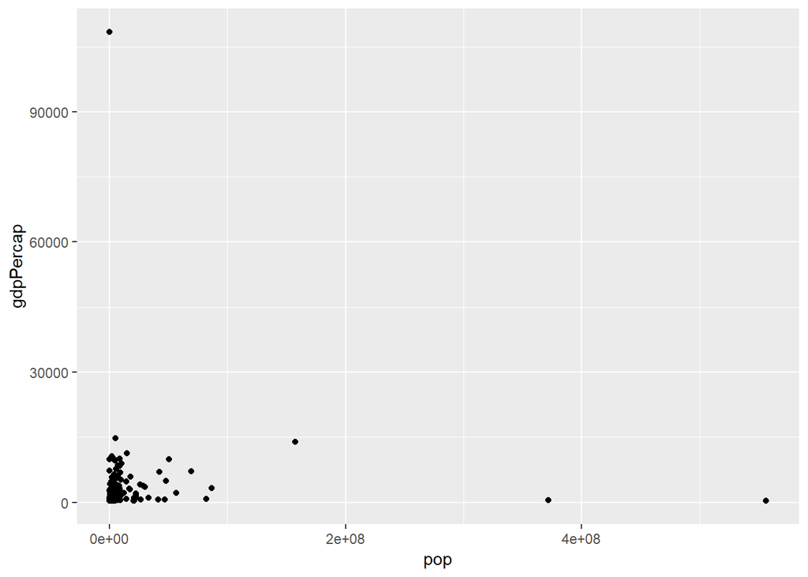

```r
ggplot(gapminder_1952, aes(x = pop, y = gdpPercap)) +
  geom_point()
```

Log scales  
從圖可以知道，點會太集中於某區使得無法解讀，這時候就要用Log scales來解決讓途更好看

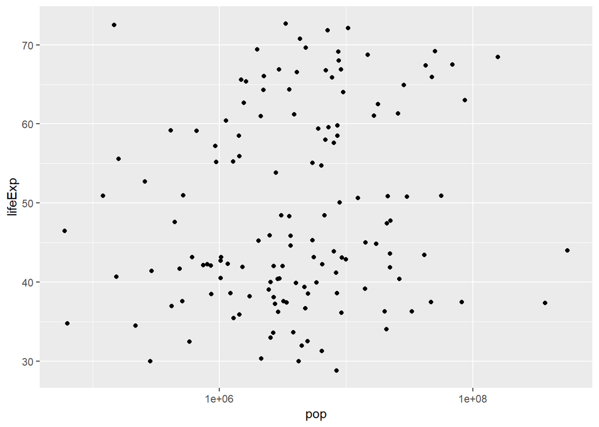

```r
ggplot(gapminder_1952, aes(x = pop, y = lifeExp)) +
  geom_point()+
  scale_x_log10()
```

假設我要畫人口和人均gdp這種都很極端的例子，最好xy都要取log

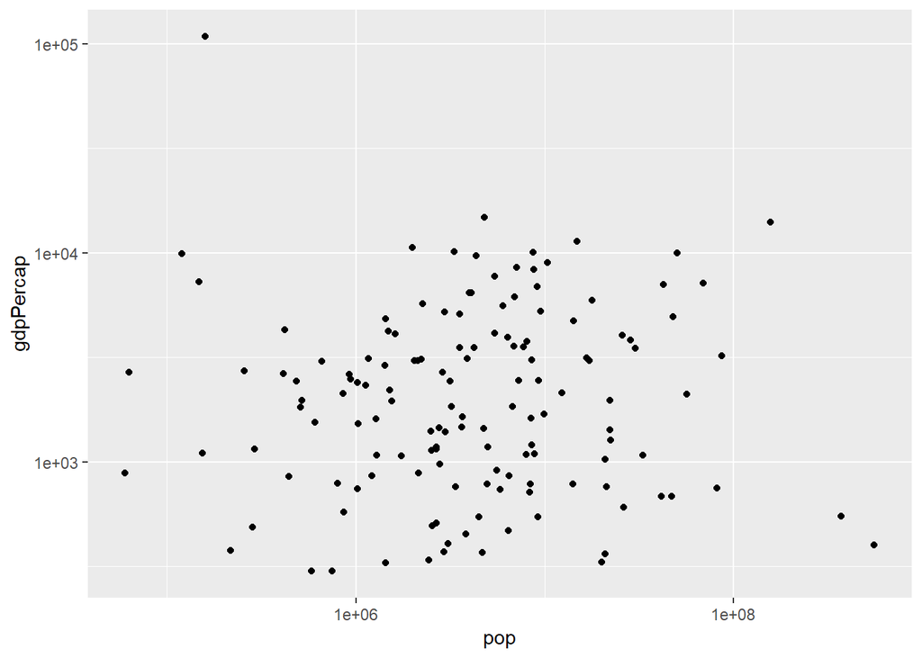

```r
ggplot(gapminder_1952, aes(x = pop, y = gdpPercap)) +
  geom_point()+
  scale_x_log10()+
  scale_y_log10()
```

Additional aesthetics  
為自己的圖表加點顏色吧!比如說我想以洲分類為顏色

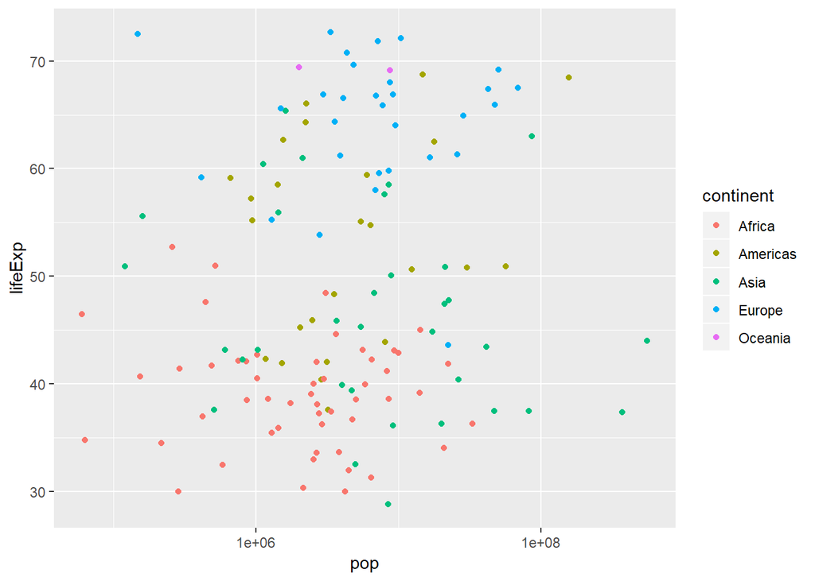

```r
ggplot(gapminder_1952, aes(x = pop, y = lifeExp,color=continent)) +
  geom_point()+
  scale_x_log10()
```

還可以調整點的大小呢!比如我現在要以人均gdp為點大小

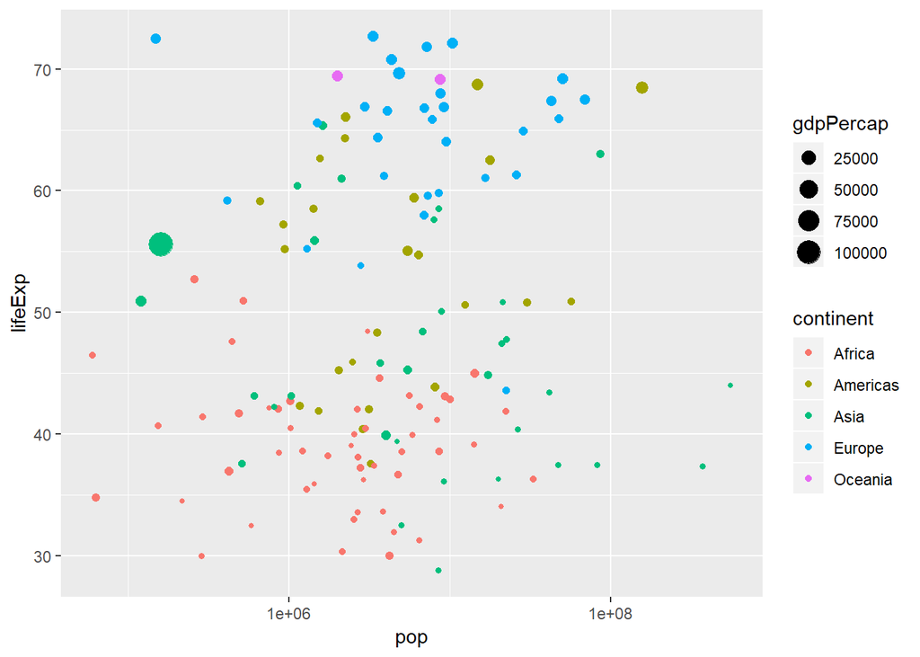

```r
ggplot(gapminder_1952, aes(x = pop, y = lifeExp, color = continent,size=gdpPercap)) +
  geom_point() +
  scale_x_log10()
```

Faceting刻面!!!  
這可以把圖表再細分成其他圖表，可以使我們更容易觀察某特性下的分布，假設我要以洲來區分x軸為人口y軸為lifeExp的特性圖表，我可以這樣做

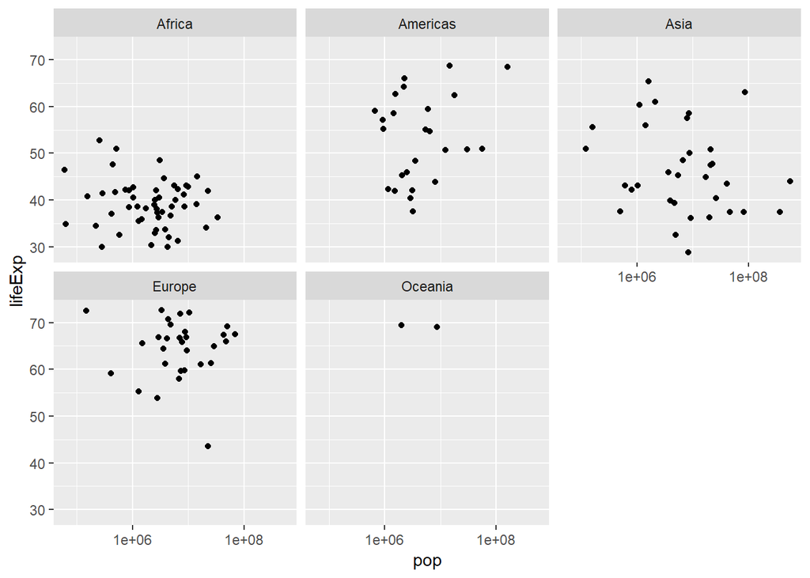

```r
ggplot(gapminder_1952, aes(x = pop, y = lifeExp)) +
  geom_point() +
  scale_x_log10()+
  facet_wrap(~continent)
```

假設我要畫1952~2007以年為faceting得圖表，x軸為人均gdp，y軸為lifeExp，洲為顏色，人口為點大小，我可以這樣做

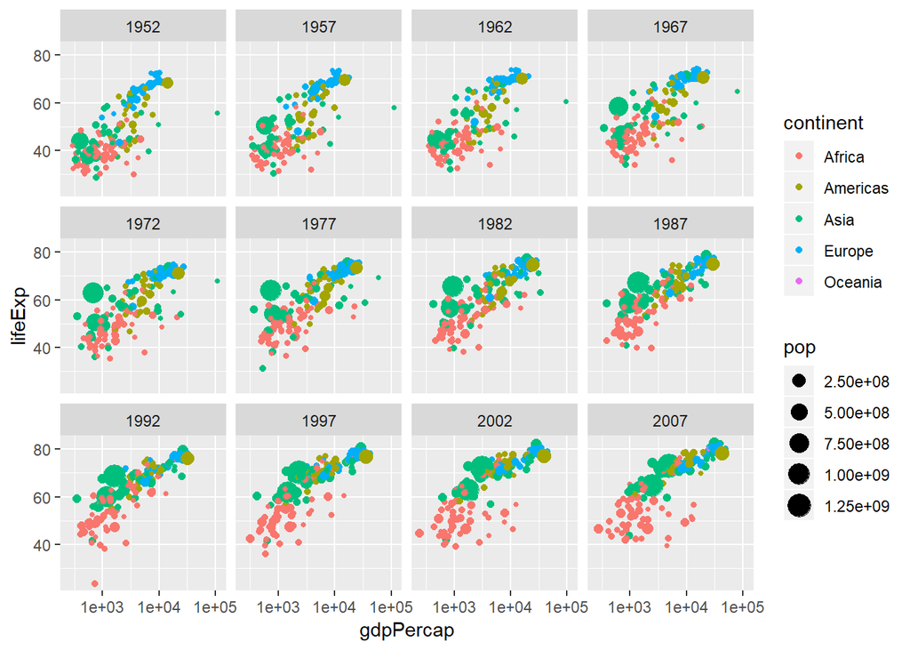

```r
ggplot(gapminder, aes(x = gdpPercap, y = lifeExp,color=continent,size=pop)) +
  geom_point() +
  scale_x_log10()+
  facet_wrap(~year)
```

## Grouping and summarizing

The summarize verb  
summarize()可以把資料統整起來，你當然也可以把他跟filter()一起使用  
假設我想統整1957年的lifeExp的中位數

```r
gapminder %>%
filter(year==1957) %>%
summarize(medianLifeExp=median(lifeExp))
```

```
## # A tibble: 1 x 1
##   medianLifeExp
##           <dbl>
## 1          48.4
```

你也可以一次summarize很多東西

```r
gapminder %>%
filter(year==1957) %>%
summarize(medianLifeExp=median(lifeExp),maxGdpPercap=max(gdpPercap))
```

```
## # A tibble: 1 x 2
##   medianLifeExp maxGdpPercap
##           <dbl>        <dbl>
## 1          48.4      113523.
```

以上可以統整出1957年人均gdp最大值和lifeExp中位數  
The group_by verb  
利用group_by()把有同元素性質的資料合併，使你接下來處理資料或分析資料更順利!

```r
gapminder %>%
 group_by(year) %>%
 summarize(medianLifeExp=median(lifeExp),maxGdpPercap=max(gdpPercap))
```

```
## # A tibble: 12 x 3
##     year medianLifeExp maxGdpPercap
##    <int>         <dbl>        <dbl>
##  1  1952          45.1      108382.
##  2  1957          48.4      113523.
##  3  1962          50.9       95458.
##  4  1967          53.8       80895.
##  5  1972          56.5      109348.
##  6  1977          59.7       59265.
##  7  1982          62.4       33693.
##  8  1987          65.8       31541.
##  9  1992          67.7       34933.
## 10  1997          69.4       41283.
## 11  2002          70.8       44684.
## 12  2007          71.9       49357.
```

這樣我就可以以每年為基準作分析且算出每年中位數和最大值唷  
當然!group_by可以混著filter使用

```r
gapminder %>%
 filter(year==1957) %>%
 group_by(continent) %>%
 summarize(medianLifeExp=median(lifeExp),maxGdpPercap=max(gdpPercap))
```

```
## # A tibble: 5 x 3
##   continent medianLifeExp maxGdpPercap
##   <fct>             <dbl>        <dbl>
## 1 Africa             40.6        5487.
## 2 Americas           56.1       14847.
## 3 Asia               48.3      113523.
## 4 Europe             67.6       17909.
## 5 Oceania            70.3       12247.
```

這樣我可以分析1957年每洲的資訊  
你也可以一次group_by()很多東西

```r
gapminder %>%
group_by(continent,year) %>%
summarize(medianLifeExp=median(lifeExp),maxGdpPercap=max(gdpPercap))
```

```
## # A tibble: 60 x 4
## # Groups:   continent [?]
##    continent  year medianLifeExp maxGdpPercap
##    <fct>     <int>         <dbl>        <dbl>
##  1 Africa     1952          38.8        4725.
##  2 Africa     1957          40.6        5487.
##  3 Africa     1962          42.6        6757.
##  4 Africa     1967          44.7       18773.
##  5 Africa     1972          47.0       21011.
##  6 Africa     1977          49.3       21951.
##  7 Africa     1982          50.8       17364.
##  8 Africa     1987          51.6       11864.
##  9 Africa     1992          52.4       13522.
## 10 Africa     1997          52.8       14723.
## # ... with 50 more rows
```

這樣我就可以看到每年各洲的情形了  
Visualizing summarized data  
我們先把整理好的資料指令起來，然後開始畫圖

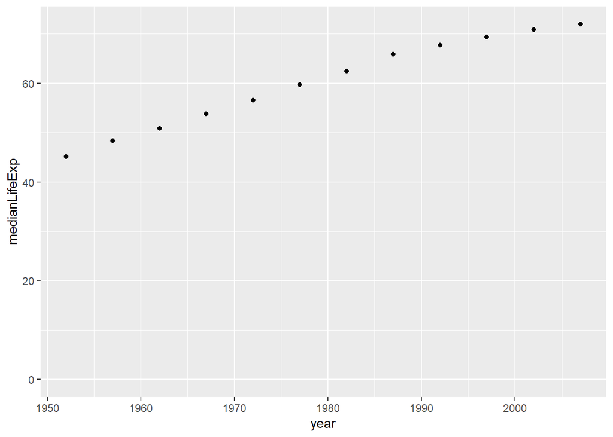

```r
by_year <- gapminder %>%
  group_by(year) %>%
  summarize(medianLifeExp = median(lifeExp),
            maxGdpPercap = max(gdpPercap))
ggplot(by_year, aes(x = year, y = medianLifeExp)) +
  geom_point() +
  expand_limits(y = 0)
```

請注意，如果要讓y值一開始是0，你必須加上expand_limits(y = 0)才行。

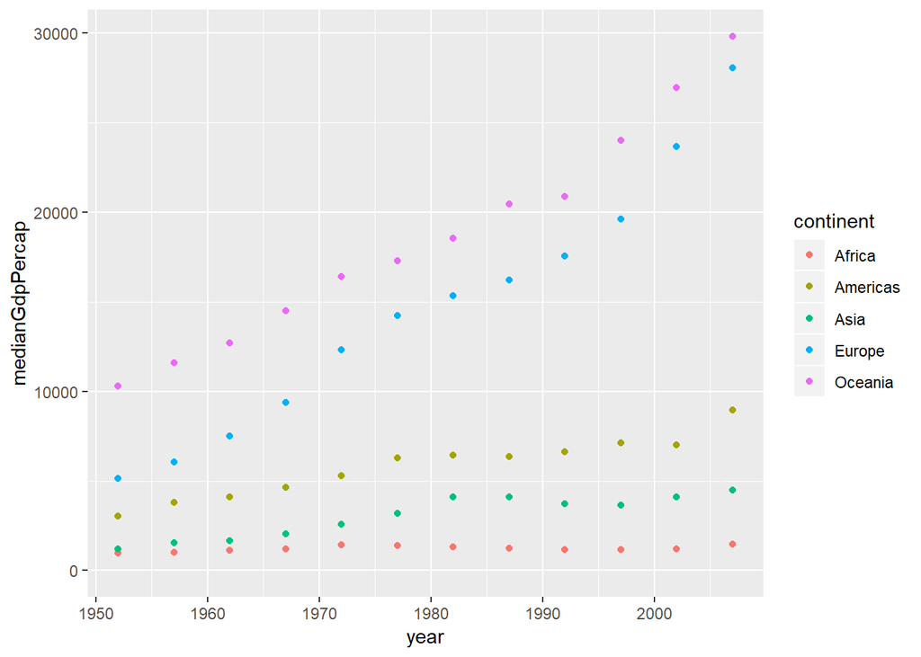

```r
by_year_continent<- gapminder %>%
group_by(year,continent) %>%
summarize(medianGdpPercap=median(gdpPercap))
ggplot(by_year_continent,aes(x=year,y=medianGdpPercap,color=continent)) +
geom_point() +
expand_limits(y = 0)
```

這張圖很完整呈現各洲中位數人均gdp的情況。

## Types of visualizations

Line plots  
把geom_point改成geom_line就是了

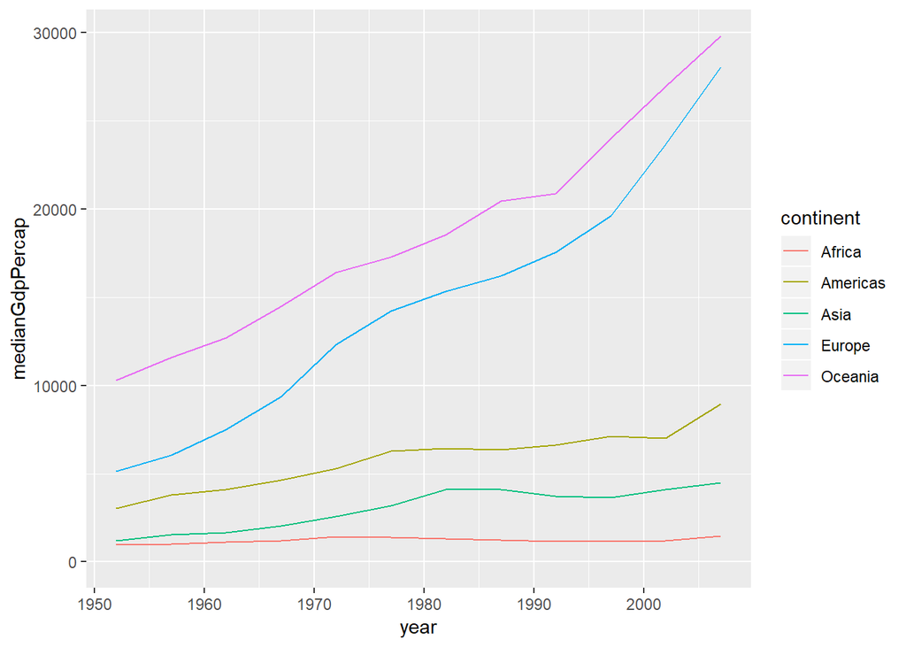

```r
by_year_continent<-gapminder %>%
group_by(year,continent) %>%
summarize(medianGdpPercap=median(gdpPercap))
ggplot(by_year_continent,aes(x=year,y=medianGdpPercap,color=continent))+
geom_line()+
expand_limits(y=0)
```

這樣可以看出不同洲中位數人均gdp歷年來的變化  
Bar plots  
把geom_point改成geom_col就是了

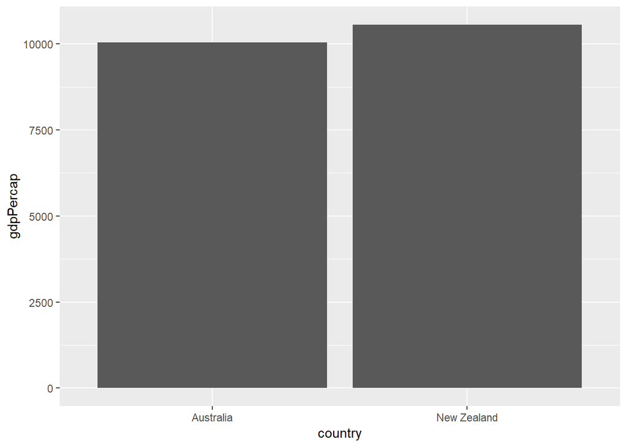

```r
oceania_1952<-gapminder %>%
filter(year==1952,continent=='Oceania')
ggplot(oceania_1952,aes(x=country,y=gdpPercap))+
geom_col()
```

這樣就是紐西蘭和澳洲人均gdp的長條圖了!  
Histograms  
把geom_point改成geom_histogram就是了  
geom_histogram()括號裡面還可以加bindwith=數字

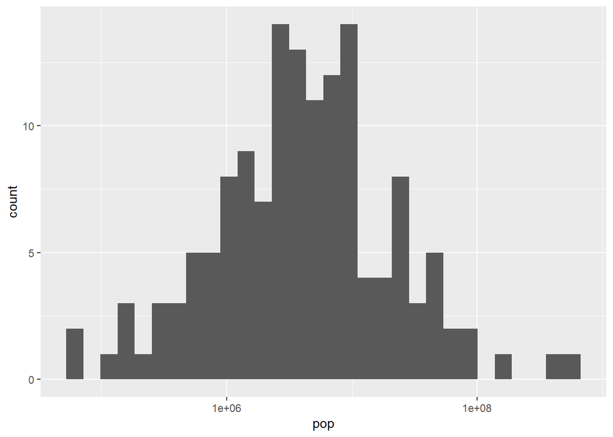

```r
gapminder_1952 <- gapminder %>%
  filter(year == 1952)
ggplot(gapminder_1952,aes(x=pop))+
geom_histogram()+
scale_x_log10()
```

如果沒有cale_x_log10那一行程式碼，整張圖繪整個偏又且不易讀!  
Boxplots  
把geom_point改成geom_boxplot就是了  
用lab()可以加標題title=“xxx”

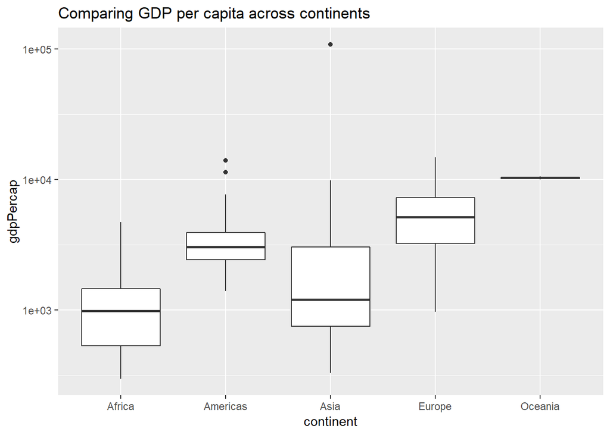

```r
gapminder_1952 <- gapminder %>%
  filter(year == 1952)
ggplot(gapminder_1952, aes(x = continent, y = gdpPercap)) +
  geom_boxplot() +
  scale_y_log10()+
  labs(title='Comparing GDP per capita across continents')
```

- 回目錄